# Cython

```python
%matplotlib inline
import matplotlib.pyplot as plt
plt.rcParams['figure.figsize'] = (10,6)
%config InlineBackend.figure_format = 'retina'
import numpy as np
```

```python
import warnings
warnings.filterwarnings("ignore")
```

[figure not shown]

- Cython provides extra syntax allowing for static type declarations (remember: Python is generally dynamically typed)
- Python code gets translated into optimised C/C++ code and compiled as Python extension modules
- Cython allows you to write fast C code in a Python-like syntax.
- Furthermore, linking to existing C libraries is simplified.
- Pure Python Function

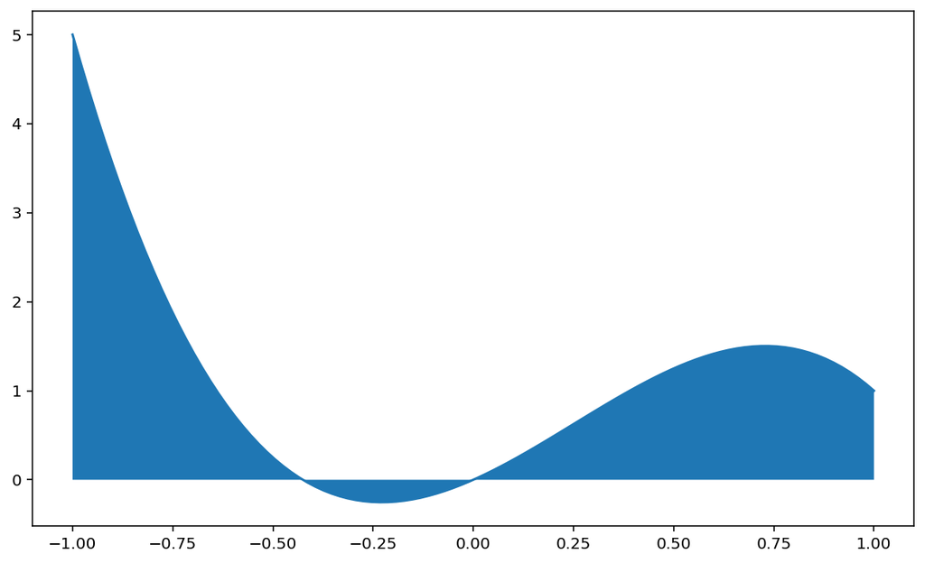

```python
def f(x):
    return -4*x**3 +3*x**2 +2*x

x = np.linspace(-1,1,100)
ax = plt.subplot(1,1,1)
ax.plot(x, f(x))
ax.fill_between(x, 0, f(x));
```

we compute integral $\int_a^b f(x)dx$ numerically with $N$ points.

```python
def integrate_f_py(a,b,N):
    s  = 0
    dx = (b - a) / (N-1)
    for i in range(N-1): # we intentionally use the bad way to do this with a loop
        x = a + i*dx
        s += (f(x)+f(x+dx))/2
    return s*dx
```

```python
%timeit integrate_f_py(-1,1,10**3)
print(integrate_f_py(-1,1,1000))
```

```
966 µs ± 8.58 µs per loop (mean ± std. dev. of 7 runs, 1000 loops each)
2.0000040080120174
```

```python
%load_ext heat
```

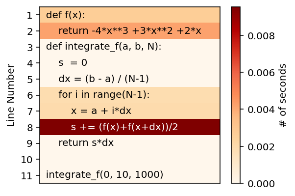

```python
%%heat
def f(x):
    return -4*x**3 +3*x**2 +2*x
def integrate_f(a, b, N):
    s  = 0
    dx = (b - a) / (N-1)
    for i in range(N-1):
        x = a + i*dx
        s += (f(x)+f(x+dx))/2
    return s*dx

integrate_f(0, 10, 1000)
```

- Pure C function

```python
%%file integral_f_c.c

#include <stdlib.h>
#include <stdio.h>
#include <time.h>

#define NB_RUNS 1000

double f(double x) {
    return -4*x*x*x +3*x*x +2*x;
}

double integrate_f_c(double a, double b, int N) {
    double s  = 0;
    double dx = (b - a) / (N-1);
    for(int i=0; i<N-1; ++i){
        double x = a + i*dx;
        s += (f(x)+f(x+dx))/2.0;
    }
    return s*dx;
}

int main(int argc, char **argv)
{

  double a =  atof(argv[1]);
  double b =  atof(argv[2]);
  int N    =  atoi(argv[3]);
  double  res = 0;

  clock_t begin = clock();

  for (int i=0; i<NB_RUNS; ++i)
      res += integrate_f_c( a, b, N );

  clock_t end = clock();

  fprintf( stdout, "integral_f(%3.1f, %3.1f, %d) = %f \n", a, b, N, res / NB_RUNS );
  fprintf( stdout, "time = %e ms \n",  (double)(end - begin) / CLOCKS_PER_SEC );

  return 0;
}
```

```
Writing integral_f_c.c
```

```python
!gcc -O3 integral_f_c.c; ./a.out -1 1 1000
```

```
integral_f(-1.0, 1.0, 1000) = 2.000004
time = 5.494000e-03 ms
```

## Cython compilation: Generating C code

Load Cython in jupyter notebook.

```python
%load_ext Cython
```

### C Variable and Type definitions

In general, use `cdef` to declare C variables. The command :

```
$ cython -a mycode.pyx
```

outputs an html file. It shows what parts of your code are C, which parts are Python, and where C-Python conversion occurs.

```python
%%cython -a
cdef int i, j = 2, k = 3      # assigning values at declaration
i = 1                         # assigning values afterwards
# avoid Python-C conversion! It's expensive:
a = 5
i = a
# same with C-Python conversion:
b = j
print("a = %d" % a)
print("i = %d" % i)
print("b = %d" % b)
```

```
a = 5
i = 5
b = 2
```

Generated by Cython 0.29.21

Yellow lines hint at Python interaction.  
Click on a line that starts with a "`+`" to see the C code that Cython generated for it.

```
+01: cdef int i, j = 2, k = 3      # assigning values at declaration
```

```
  __pyx_v_46_cython_magic_63a06d9479896e5b6c37bf1ed772a79b_j = 2;
  __pyx_v_46_cython_magic_63a06d9479896e5b6c37bf1ed772a79b_k = 3;
```

```
+02: i = 1                         # assigning values afterwards
```

```
  __pyx_v_46_cython_magic_63a06d9479896e5b6c37bf1ed772a79b_i = 1;
```

```
 03: # avoid Python-C conversion! It's expensive:
```

```
+04: a = 5
```

```
  if (PyDict_SetItem(__pyx_d, __pyx_n_s_a, __pyx_int_5) < 0) __PYX_ERR(0, 4, __pyx_L1_error)
```

```
+05: i = a
```

```
  __Pyx_GetModuleGlobalName(__pyx_t_1, __pyx_n_s_a); if (unlikely(!__pyx_t_1)) __PYX_ERR(0, 5, __pyx_L1_error)
  __Pyx_GOTREF(__pyx_t_1);
  __pyx_t_2 = __Pyx_PyInt_As_int(__pyx_t_1); if (unlikely((__pyx_t_2 == (int)-1) && PyErr_Occurred())) __PYX_ERR(0, 5, __pyx_L1_error)
  __Pyx_DECREF(__pyx_t_1); __pyx_t_1 = 0;
  __pyx_v_46_cython_magic_63a06d9479896e5b6c37bf1ed772a79b_i = __pyx_t_2;
```

```
 06: # same with C-Python conversion:
```

```
+07: b = j
```

```
  __pyx_t_1 = __Pyx_PyInt_From_int(__pyx_v_46_cython_magic_63a06d9479896e5b6c37bf1ed772a79b_j); if (unlikely(!__pyx_t_1)) __PYX_ERR(0, 7, __pyx_L1_error)
  __Pyx_GOTREF(__pyx_t_1);
  if (PyDict_SetItem(__pyx_d, __pyx_n_s_b, __pyx_t_1) < 0) __PYX_ERR(0, 7, __pyx_L1_error)
  __Pyx_DECREF(__pyx_t_1); __pyx_t_1 = 0;
```

```
+08: print("a = %d" % a)
```

```
  __Pyx_GetModuleGlobalName(__pyx_t_1, __pyx_n_s_a); if (unlikely(!__pyx_t_1)) __PYX_ERR(0, 8, __pyx_L1_error)
  __Pyx_GOTREF(__pyx_t_1);
  __pyx_t_3 = __Pyx_PyUnicode_FormatSafe(__pyx_kp_u_a_d, __pyx_t_1); if (unlikely(!__pyx_t_3)) __PYX_ERR(0, 8, __pyx_L1_error)
  __Pyx_GOTREF(__pyx_t_3);
  __Pyx_DECREF(__pyx_t_1); __pyx_t_1 = 0;
  __pyx_t_1 = __Pyx_PyObject_CallOneArg(__pyx_builtin_print, __pyx_t_3); if (unlikely(!__pyx_t_1)) __PYX_ERR(0, 8, __pyx_L1_error)
  __Pyx_GOTREF(__pyx_t_1);
  __Pyx_DECREF(__pyx_t_3); __pyx_t_3 = 0;
  __Pyx_DECREF(__pyx_t_1); __pyx_t_1 = 0;
```

```
+09: print("i = %d" % i)
```

```
  __pyx_t_1 = __Pyx_PyInt_From_int(__pyx_v_46_cython_magic_63a06d9479896e5b6c37bf1ed772a79b_i); if (unlikely(!__pyx_t_1)) __PYX_ERR(0, 9, __pyx_L1_error)
  __Pyx_GOTREF(__pyx_t_1);
  __pyx_t_3 = PyUnicode_Format(__pyx_kp_u_i_d, __pyx_t_1); if (unlikely(!__pyx_t_3)) __PYX_ERR(0, 9, __pyx_L1_error)
  __Pyx_GOTREF(__pyx_t_3);
  __Pyx_DECREF(__pyx_t_1); __pyx_t_1 = 0;
  __pyx_t_1 = __Pyx_PyObject_CallOneArg(__pyx_builtin_print, __pyx_t_3); if (unlikely(!__pyx_t_1)) __PYX_ERR(0, 9, __pyx_L1_error)
  __Pyx_GOTREF(__pyx_t_1);
  __Pyx_DECREF(__pyx_t_3); __pyx_t_3 = 0;
  __Pyx_DECREF(__pyx_t_1); __pyx_t_1 = 0;
```

```
+10: print("b = %d" % b)
```

```
  __Pyx_GetModuleGlobalName(__pyx_t_1, __pyx_n_s_b); if (unlikely(!__pyx_t_1)) __PYX_ERR(0, 10, __pyx_L1_error)
  __Pyx_GOTREF(__pyx_t_1);
  __pyx_t_3 = __Pyx_PyUnicode_FormatSafe(__pyx_kp_u_b_d, __pyx_t_1); if (unlikely(!__pyx_t_3)) __PYX_ERR(0, 10, __pyx_L1_error)
  __Pyx_GOTREF(__pyx_t_3);
  __Pyx_DECREF(__pyx_t_1); __pyx_t_1 = 0;
  __pyx_t_1 = __Pyx_PyObject_CallOneArg(__pyx_builtin_print, __pyx_t_3); if (unlikely(!__pyx_t_1)) __PYX_ERR(0, 10, __pyx_L1_error)
  __Pyx_GOTREF(__pyx_t_1);
  __Pyx_DECREF(__pyx_t_3); __pyx_t_3 = 0;
  __Pyx_DECREF(__pyx_t_1); __pyx_t_1 = 0;
```

### Another Python vs. Cython coloring guide

```python
%%cython -a
cdef int m, n
cdef double cy_total = 0.0
for m in range(10):
    n = 2*m
    cy_total += n
a, b = 0, 0
py_total = 0.0
for a in range(10):
    b = 2*a
    py_total += b
print(cy_total, py_total)
```

```
90.0 90.0
```

Generated by Cython 0.29.21

Yellow lines hint at Python interaction.  
Click on a line that starts with a "`+`" to see the C code that Cython generated for it.

```
 01: cdef int m, n
```

```
+02: cdef double cy_total = 0.0
```

```
  __pyx_v_46_cython_magic_ba932445a0c0f1978bb32889380f1ef0_cy_total = 0.0;
```

```
+03: for m in range(10):
```

```
  for (__pyx_t_1 = 0; __pyx_t_1 < 10; __pyx_t_1+=1) {
    __pyx_v_46_cython_magic_ba932445a0c0f1978bb32889380f1ef0_m = __pyx_t_1;
```

```
+04:     n = 2*m
```

```
    __pyx_v_46_cython_magic_ba932445a0c0f1978bb32889380f1ef0_n = (2 * __pyx_v_46_cython_magic_ba932445a0c0f1978bb32889380f1ef0_m);
```

```
+05:     cy_total += n
```

```
    __pyx_v_46_cython_magic_ba932445a0c0f1978bb32889380f1ef0_cy_total = (__pyx_v_46_cython_magic_ba932445a0c0f1978bb32889380f1ef0_cy_total + __pyx_v_46_cython_magic_ba932445a0c0f1978bb32889380f1ef0_n);
  }
```

```
+06: a, b = 0, 0
```

```
  __pyx_t_2 = __pyx_int_0;
  __Pyx_INCREF(__pyx_t_2);
  __pyx_t_3 = __pyx_int_0;
  __Pyx_INCREF(__pyx_t_3);
  if (PyDict_SetItem(__pyx_d, __pyx_n_s_a, __pyx_t_2) < 0) __PYX_ERR(0, 6, __pyx_L1_error)
  __Pyx_DECREF(__pyx_t_2); __pyx_t_2 = 0;
  if (PyDict_SetItem(__pyx_d, __pyx_n_s_b, __pyx_t_3) < 0) __PYX_ERR(0, 6, __pyx_L1_error)
  __Pyx_DECREF(__pyx_t_3); __pyx_t_3 = 0;
```

```
+07: py_total = 0.0
```

```
  if (PyDict_SetItem(__pyx_d, __pyx_n_s_py_total, __pyx_float_0_0) < 0) __PYX_ERR(0, 7, __pyx_L1_error)
```

```
+08: for a in range(10):
```

```
  for (__pyx_t_4 = 0; __pyx_t_4 < 10; __pyx_t_4+=1) {
    __pyx_t_3 = __Pyx_PyInt_From_long(__pyx_t_4); if (unlikely(!__pyx_t_3)) __PYX_ERR(0, 8, __pyx_L1_error)
    __Pyx_GOTREF(__pyx_t_3);
    if (PyDict_SetItem(__pyx_d, __pyx_n_s_a, __pyx_t_3) < 0) __PYX_ERR(0, 8, __pyx_L1_error)
    __Pyx_DECREF(__pyx_t_3); __pyx_t_3 = 0;
```

```
+09:     b = 2*a
```

```
    __Pyx_GetModuleGlobalName(__pyx_t_3, __pyx_n_s_a); if (unlikely(!__pyx_t_3)) __PYX_ERR(0, 9, __pyx_L1_error)
    __Pyx_GOTREF(__pyx_t_3);
    __pyx_t_2 = PyNumber_Multiply(__pyx_int_2, __pyx_t_3); if (unlikely(!__pyx_t_2)) __PYX_ERR(0, 9, __pyx_L1_error)
    __Pyx_GOTREF(__pyx_t_2);
    __Pyx_DECREF(__pyx_t_3); __pyx_t_3 = 0;
    if (PyDict_SetItem(__pyx_d, __pyx_n_s_b, __pyx_t_2) < 0) __PYX_ERR(0, 9, __pyx_L1_error)
    __Pyx_DECREF(__pyx_t_2); __pyx_t_2 = 0;
```

```
+10:     py_total += b
```

```
    __Pyx_GetModuleGlobalName(__pyx_t_2, __pyx_n_s_py_total); if (unlikely(!__pyx_t_2)) __PYX_ERR(0, 10, __pyx_L1_error)
    __Pyx_GOTREF(__pyx_t_2);
    __Pyx_GetModuleGlobalName(__pyx_t_3, __pyx_n_s_b); if (unlikely(!__pyx_t_3)) __PYX_ERR(0, 10, __pyx_L1_error)
    __Pyx_GOTREF(__pyx_t_3);
    __pyx_t_5 = PyNumber_InPlaceAdd(__pyx_t_2, __pyx_t_3); if (unlikely(!__pyx_t_5)) __PYX_ERR(0, 10, __pyx_L1_error)
    __Pyx_GOTREF(__pyx_t_5);
    __Pyx_DECREF(__pyx_t_2); __pyx_t_2 = 0;
    __Pyx_DECREF(__pyx_t_3); __pyx_t_3 = 0;
    if (PyDict_SetItem(__pyx_d, __pyx_n_s_py_total, __pyx_t_5) < 0) __PYX_ERR(0, 10, __pyx_L1_error)
    __Pyx_DECREF(__pyx_t_5); __pyx_t_5 = 0;
  }
```

```
+11: print(cy_total, py_total)
```

```
  __pyx_t_5 = PyFloat_FromDouble(__pyx_v_46_cython_magic_ba932445a0c0f1978bb32889380f1ef0_cy_total); if (unlikely(!__pyx_t_5)) __PYX_ERR(0, 11, __pyx_L1_error)
  __Pyx_GOTREF(__pyx_t_5);
  __Pyx_GetModuleGlobalName(__pyx_t_3, __pyx_n_s_py_total); if (unlikely(!__pyx_t_3)) __PYX_ERR(0, 11, __pyx_L1_error)
  __Pyx_GOTREF(__pyx_t_3);
  __pyx_t_2 = PyTuple_New(2); if (unlikely(!__pyx_t_2)) __PYX_ERR(0, 11, __pyx_L1_error)
  __Pyx_GOTREF(__pyx_t_2);
  __Pyx_GIVEREF(__pyx_t_5);
  PyTuple_SET_ITEM(__pyx_t_2, 0, __pyx_t_5);
  __Pyx_GIVEREF(__pyx_t_3);
  PyTuple_SET_ITEM(__pyx_t_2, 1, __pyx_t_3);
  __pyx_t_5 = 0;
  __pyx_t_3 = 0;
  __pyx_t_3 = __Pyx_PyObject_Call(__pyx_builtin_print, __pyx_t_2, NULL); if (unlikely(!__pyx_t_3)) __PYX_ERR(0, 11, __pyx_L1_error)
  __Pyx_GOTREF(__pyx_t_3);
  __Pyx_DECREF(__pyx_t_2); __pyx_t_2 = 0;
  __Pyx_DECREF(__pyx_t_3); __pyx_t_3 = 0;
```

```python
%%cython -a
cdef struct Grail:
    int age
    float volume
cdef union Food:
    char *spam
    float *eggs
cdef enum CheeseType:
    cheddar, edam,
    camembert
cdef enum CheeseState:
    hard = 1
    soft = 2
    runny = 3
cdef Grail holy
holy.age    = 500
holy.volume = 10.0
print (holy.age, holy.volume)
```

```
500 10.0
```

Generated by Cython 0.29.21

Yellow lines hint at Python interaction.  
Click on a line that starts with a "`+`" to see the C code that Cython generated for it.

```
+01: cdef struct Grail:
```

```
struct __pyx_t_46_cython_magic_8fbcdf7089af097dc2f5ac0bde854da0_Grail {
  int age;
  float volume;
};
```

```
 02:     int age
```

```
 03:     float volume
```

```
 04: cdef union Food:
```

```
 05:     char *spam
```

```
 06:     float *eggs
```

```
+07: cdef enum CheeseType:
```

```
enum __pyx_t_46_cython_magic_8fbcdf7089af097dc2f5ac0bde854da0_CheeseType {
  __pyx_e_46_cython_magic_8fbcdf7089af097dc2f5ac0bde854da0_cheddar,
  __pyx_e_46_cython_magic_8fbcdf7089af097dc2f5ac0bde854da0_edam,
  __pyx_e_46_cython_magic_8fbcdf7089af097dc2f5ac0bde854da0_camembert
};
```

```
 08:     cheddar, edam,
```

```
 09:     camembert
```

```
+10: cdef enum CheeseState:
```

```
enum __pyx_t_46_cython_magic_8fbcdf7089af097dc2f5ac0bde854da0_CheeseState {
  __pyx_e_46_cython_magic_8fbcdf7089af097dc2f5ac0bde854da0_hard = 1,
  __pyx_e_46_cython_magic_8fbcdf7089af097dc2f5ac0bde854da0_soft = 2,
  __pyx_e_46_cython_magic_8fbcdf7089af097dc2f5ac0bde854da0_runny = 3
};
```

```
 11:     hard = 1
```

```
 12:     soft = 2
```

```
 13:     runny = 3
```

```
 14: cdef Grail holy
```

```
+15: holy.age    = 500
```

```
  __pyx_v_46_cython_magic_8fbcdf7089af097dc2f5ac0bde854da0_holy.age = 0x1F4;
```

```
+16: holy.volume = 10.0
```

```
  __pyx_v_46_cython_magic_8fbcdf7089af097dc2f5ac0bde854da0_holy.volume = 10.0;
```

```
+17: print (holy.age, holy.volume)
```

```
  __pyx_t_1 = __Pyx_PyInt_From_int(__pyx_v_46_cython_magic_8fbcdf7089af097dc2f5ac0bde854da0_holy.age); if (unlikely(!__pyx_t_1)) __PYX_ERR(0, 17, __pyx_L1_error)
  __Pyx_GOTREF(__pyx_t_1);
  __pyx_t_2 = PyFloat_FromDouble(__pyx_v_46_cython_magic_8fbcdf7089af097dc2f5ac0bde854da0_holy.volume); if (unlikely(!__pyx_t_2)) __PYX_ERR(0, 17, __pyx_L1_error)
  __Pyx_GOTREF(__pyx_t_2);
  __pyx_t_3 = PyTuple_New(2); if (unlikely(!__pyx_t_3)) __PYX_ERR(0, 17, __pyx_L1_error)
  __Pyx_GOTREF(__pyx_t_3);
  __Pyx_GIVEREF(__pyx_t_1);
  PyTuple_SET_ITEM(__pyx_t_3, 0, __pyx_t_1);
  __Pyx_GIVEREF(__pyx_t_2);
  PyTuple_SET_ITEM(__pyx_t_3, 1, __pyx_t_2);
  __pyx_t_1 = 0;
  __pyx_t_2 = 0;
  __pyx_t_2 = __Pyx_PyObject_Call(__pyx_builtin_print, __pyx_t_3, NULL); if (unlikely(!__pyx_t_2)) __PYX_ERR(0, 17, __pyx_L1_error)
  __Pyx_GOTREF(__pyx_t_2);
  __Pyx_DECREF(__pyx_t_3); __pyx_t_3 = 0;
  __Pyx_DECREF(__pyx_t_2); __pyx_t_2 = 0;
```

## Cython Functions

Use **cdef** to define a Cython function.

- Cython function can accept either (inclusive) Python and C values as well as return either Python or C values,
- *Within a Cython module* Python and Cython functions can call each other freely. However, only **Python** functions can be called from outside the module by Python code. (i.e. importing/exporting a Cython module into some Python code)

**cpdef** define a Cython function with a simple Python wrapper. However, when called from Cython the Cython / C code is called directly, bypassing the Python wrapper.

Writing pure code in Cython gives a small speed boost. Note that none of the code below is Cython-specific. Just add `.pyx` instead of `.py` extension.

```python
%%file cython_f_example.pyx
def f(x):
    return -4*x**3 +3*x**2 +2*x
def integrate_f(a, b, N):
    s  = 0
    dx = (b - a) / (N-1)
    for i in range(N-1):
        x = a + i*dx
        s += (f(x)+f(x+dx))/2
    return s*dx
```

```
Writing cython_f_example.pyx
```

## Cython Compilation

- The .pyx source file is compiled by Cython to a .c file.
- The .c source file contains the code of a Python extension module.
- The .c file is compiled by a C compiler to a .so (shared object library) file which can be imported directly into a Python session.

### Build with CMake

```
project(cython_f_example CXX)
include(UseCython)  # Load Cython functions
# Set C++ output
set_source_file_properties(cython_f_example.pyx PROPERTIES CYTHON_IS_CXX TRUE )
# Build the extension module
cython_add_module( modname cython_f_example.pyx cython_f_example.cpp )
```

### C/C++ generation with cython application

```
cython -3 cython_f_example.pyx   # create the C file for Python 3
cython -3 --cplus cython_f_example.pyx  # create the C++ file for Python 3
```

### build with a C/C++ compiler

To build use the Makefile:

```
CC=gcc
CFLAGS=`python-config --cflags`
LDFLAGS=`python-config --ldflags`
cython_f_example:
     ${CC} -c $@.c ${CFLAGS}
     ${CC} $@.o -o $@.so -shared ${LDFLAGS}
```

Import the module in Python session

```
import cython_f_example
```

## pyximport

import Cython .pyx files as if they were .py files:

```python
import pyximport
pyximport.install()
import cython_f_example
%timeit cython_f_example.integrate_f(-1,1,10**3)
print(cython_f_example.integrate_f(-1,1,1000))
```

```
760 µs ± 4.58 µs per loop (mean ± std. dev. of 7 runs, 1000 loops each)
2.0000040080120174
```

## Building a Cython module using distutils

Create the setup.py script:

```python
%%file setup.py
from distutils.core import setup
from Cython.Build import cythonize

setup(
  name = 'Cython Example Integrate f Function',
  ext_modules = cythonize("cython_f_example.pyx"),
)
```

```
Writing setup.py
```

```python
%run setup.py  build_ext --inplace --quiet
```

[output not shown]

```python
from cython_f_example import integrate_f
%timeit integrate_f(-1,1,10**3)
integrate_f(-1,1,10**3)
```

```
772 µs ± 12.3 µs per loop (mean ± std. dev. of 7 runs, 1000 loops each)
```

```
2.0000040080120174
```

## Why is it faster with Cython ?

- Python code is interpreted at every execution to machine code.
- Compiled C code is already in machine code.
- C is a statically-typed language. It gives to the compiler more information which allows it to optimize both computations and memory access.
- To add two variables, Python checks the type before calling the right **add** function and store it to a value that can be new.
- C just add the variables and return the result.

## Add Cython types

We coerce Python types to C types when calling the function. Still a "Python function" so callable from the global namespace.

```python
%%cython
def f(x):
    return -4*x**3 +3*x**2 +2*x
def cy_integrate_f(double a, double b, int N):
    cdef int i
    cdef double s, x, dx
    s  = 0
    dx = (b - a) / (N-1)
    for i in range(N-1):
        x = a + i*dx
        s += (f(x)+f(x+dx))/2
    return s*dx
```

[output not shown]

- typing the iterator variable i with C semantics, tells Cython to compile the for-loop to pure C code.
- typing a, s and dx is important as they are involved in arithmetic within the for-loop
- Cython type declarations can make the source code less readable
- Do not use them without good reason, i.e. only in performance critical sections.

```python
%timeit cy_integrate_f(-1,1,10**3)
print(cy_integrate_f(-1,1,1000))
```

```
685 µs ± 9.54 µs per loop (mean ± std. dev. of 7 runs, 1000 loops each)
2.0000040080120174
```

Finally, we integrate a Cython function instead of a Python function. This eliminates the Python-C conversion at the function call as seen above thus giving a pure Cython/C algorithm.

The primary downside is not being allowed to call the function `cy_f`, from Python unless `cpdef` is used.

```python
%%cython
cdef double cy_f(double x):
    return -4*x**3 +3*x**2 +2*x
def cycy_integrate_f(double a, double b, int N):
    cdef int i
    cdef double s, x, dx
    s  = 0
    dx = (b - a) / (N-1)
    for i in range(N-1):
        x = a + i*dx
        s += (cy_f(x)+cy_f(x+dx))/2
    return s*dx
```

[output not shown]

```python
%timeit cycy_integrate_f(-1,1,10**3)
print(cycy_integrate_f(-1,1,1000))
```

```
164 µs ± 614 ns per loop (mean ± std. dev. of 7 runs, 10000 loops each)
2.0000040080120174
```

## Exercise : Cythonize the trivial exponential function.

```python
%%cython -a
def exp_python(x,terms=50):
    sum = 0.
    power = 1.
    fact = 1.
    for i in range(terms):
        sum += power/fact
        power *= x
        fact *= i+1
    return sum
```

[output not shown]

Generated by Cython 0.29.21

Yellow lines hint at Python interaction.  
Click on a line that starts with a "`+`" to see the C code that Cython generated for it.

```
+1: def exp_python(x,terms=50):
```

[output not shown]

[output cut: 48 more lines]

```
  __Pyx_XDECREF(__pyx_v_fact);
  __Pyx_XDECREF(__pyx_v_i);
  __Pyx_XGIVEREF(__pyx_r);
  __Pyx_RefNannyFinishContext();
  return __pyx_r;
}
/* … */
  __pyx_tuple_ = PyTuple_Pack(6, __pyx_n_s_x, __pyx_n_s_terms, __pyx_n_s_sum, __pyx_n_s_power, __pyx_n_s_fact, __pyx_n_s_i); if (unlikely(!__pyx_tuple_)) __PYX_ERR(0, 1, __pyx_L1_error)
  __Pyx_GOTREF(__pyx_tuple_);
  __Pyx_GIVEREF(__pyx_tuple_);
/* … */
  __pyx_t_1 = PyCFunction_NewEx(&__pyx_mdef_46_cython_magic_a96a095f6c3175b142027432bac51f88_1exp_python, NULL, __pyx_n_s_cython_magic_a96a095f6c3175b142); if (unlikely(!__pyx_t_1)) __PYX_ERR(0, 1, __pyx_L1_error)
  __Pyx_GOTREF(__pyx_t_1);
  if (PyDict_SetItem(__pyx_d, __pyx_n_s_exp_python, __pyx_t_1) < 0) __PYX_ERR(0, 1, __pyx_L1_error)
  __Pyx_DECREF(__pyx_t_1); __pyx_t_1 = 0;
```

```
+2:     sum = 0.
```

```
  __Pyx_INCREF(__pyx_float_0_);
  __pyx_v_sum = __pyx_float_0_;
```

```
+3:     power = 1.
```

```
  __Pyx_INCREF(__pyx_float_1_);
  __pyx_v_power = __pyx_float_1_;
```

```
+4:     fact = 1.
```

```
  __Pyx_INCREF(__pyx_float_1_);
  __pyx_v_fact = __pyx_float_1_;
```

```
+5:     for i in range(terms):
```

```
  __pyx_t_1 = __Pyx_PyObject_CallOneArg(__pyx_builtin_range, __pyx_v_terms); if (unlikely(!__pyx_t_1)) __PYX_ERR(0, 5, __pyx_L1_error)
  __Pyx_GOTREF(__pyx_t_1);
  if (likely(PyList_CheckExact(__pyx_t_1)) || PyTuple_CheckExact(__pyx_t_1)) {
    __pyx_t_2 = __pyx_t_1; __Pyx_INCREF(__pyx_t_2); __pyx_t_3 = 0;
    __pyx_t_4 = NULL;
  } else {
    __pyx_t_3 = -1; __pyx_t_2 = PyObject_GetIter(__pyx_t_1); if (unlikely(!__pyx_t_2)) __PYX_ERR(0, 5, __pyx_L1_error)
    __Pyx_GOTREF(__pyx_t_2);
    __pyx_t_4 = Py_TYPE(__pyx_t_2)->tp_iternext; if (unlikely(!__pyx_t_4)) __PYX_ERR(0, 5, __pyx_L1_error)
  }
  __Pyx_DECREF(__pyx_t_1); __pyx_t_1 = 0;
  for (;;) {
    if (likely(!__pyx_t_4)) {
      if (likely(PyList_CheckExact(__pyx_t_2))) {
        if (__pyx_t_3 >= PyList_GET_SIZE(__pyx_t_2)) break;
        #if CYTHON_ASSUME_SAFE_MACROS && !CYTHON_AVOID_BORROWED_REFS
        __pyx_t_1 = PyList_GET_ITEM(__pyx_t_2, __pyx_t_3); __Pyx_INCREF(__pyx_t_1); __pyx_t_3++; if (unlikely(0 < 0)) __PYX_ERR(0, 5, __pyx_L1_error)
        #else
        __pyx_t_1 = PySequence_ITEM(__pyx_t_2, __pyx_t_3); __pyx_t_3++; if (unlikely(!__pyx_t_1)) __PYX_ERR(0, 5, __pyx_L1_error)
        __Pyx_GOTREF(__pyx_t_1);
        #endif
      } else {
        if (__pyx_t_3 >= PyTuple_GET_SIZE(__pyx_t_2)) break;
        #if CYTHON_ASSUME_SAFE_MACROS && !CYTHON_AVOID_BORROWED_REFS
        __pyx_t_1 = PyTuple_GET_ITEM(__pyx_t_2, __pyx_t_3); __Pyx_INCREF(__pyx_t_1); __pyx_t_3++; if (unlikely(0 < 0)) __PYX_ERR(0, 5, __pyx_L1_error)
        #else
        __pyx_t_1 = PySequence_ITEM(__pyx_t_2, __pyx_t_3); __pyx_t_3++; if (unlikely(!__pyx_t_1)) __PYX_ERR(0, 5, __pyx_L1_error)
        __Pyx_GOTREF(__pyx_t_1);
        #endif
      }
    } else {
      __pyx_t_1 = __pyx_t_4(__pyx_t_2);
      if (unlikely(!__pyx_t_1)) {
        PyObject* exc_type = PyErr_Occurred();
        if (exc_type) {
          if (likely(__Pyx_PyErr_GivenExceptionMatches(exc_type, PyExc_StopIteration))) PyErr_Clear();
          else __PYX_ERR(0, 5, __pyx_L1_error)
        }
        break;
      }
      __Pyx_GOTREF(__pyx_t_1);
    }
    __Pyx_XDECREF_SET(__pyx_v_i, __pyx_t_1);
    __pyx_t_1 = 0;
/* … */
  }
  __Pyx_DECREF(__pyx_t_2); __pyx_t_2 = 0;
```

```
+6:         sum += power/fact
```

```
    __pyx_t_1 = __Pyx_PyNumber_Divide(__pyx_v_power, __pyx_v_fact); if (unlikely(!__pyx_t_1)) __PYX_ERR(0, 6, __pyx_L1_error)
    __Pyx_GOTREF(__pyx_t_1);
    __pyx_t_5 = PyNumber_InPlaceAdd(__pyx_v_sum, __pyx_t_1); if (unlikely(!__pyx_t_5)) __PYX_ERR(0, 6, __pyx_L1_error)
    __Pyx_GOTREF(__pyx_t_5);
    __Pyx_DECREF(__pyx_t_1); __pyx_t_1 = 0;
    __Pyx_DECREF_SET(__pyx_v_sum, __pyx_t_5);
    __pyx_t_5 = 0;
```

```
+7:         power *= x
```

```
    __pyx_t_5 = PyNumber_InPlaceMultiply(__pyx_v_power, __pyx_v_x); if (unlikely(!__pyx_t_5)) __PYX_ERR(0, 7, __pyx_L1_error)
    __Pyx_GOTREF(__pyx_t_5);
    __Pyx_DECREF_SET(__pyx_v_power, __pyx_t_5);
    __pyx_t_5 = 0;
```

```
+8:         fact *= i+1
```

```
    __pyx_t_5 = __Pyx_PyInt_AddObjC(__pyx_v_i, __pyx_int_1, 1, 0, 0); if (unlikely(!__pyx_t_5)) __PYX_ERR(0, 8, __pyx_L1_error)
    __Pyx_GOTREF(__pyx_t_5);
    __pyx_t_1 = PyNumber_InPlaceMultiply(__pyx_v_fact, __pyx_t_5); if (unlikely(!__pyx_t_1)) __PYX_ERR(0, 8, __pyx_L1_error)
    __Pyx_GOTREF(__pyx_t_1);
    __Pyx_DECREF(__pyx_t_5); __pyx_t_5 = 0;
    __Pyx_DECREF_SET(__pyx_v_fact, __pyx_t_1);
    __pyx_t_1 = 0;
```

```
+9:     return sum
```

```
  __Pyx_XDECREF(__pyx_r);
  __Pyx_INCREF(__pyx_v_sum);
  __pyx_r = __pyx_v_sum;
  goto __pyx_L0;
```

```python
%timeit exp_python(1.,50)
```

```
4.02 µs ± 32.3 ns per loop (mean ± std. dev. of 7 runs, 100000 loops each)
```

## Cython and Numpy

The Numpy library contains many fast numerics routines. Their speed comes from manipulating the low-level C-arrays that the numpy.array object wraps rather than computing over slow Python lists. Using Cython one can access those low-level arrays and implement their own fast algorithms while allowing the easy interaction afforded by Python + Numpy.

The examples below are various implementations of the naive matrix multiplication algorithm. We will start with a pure Python implementation and then incrementally add structures that allow Cython to exploit the low-level speed of the numpy.array object.

### Pure Python implementation compiled in Cython without specific optimizations.

```python
%%cython
def matmul1(A, B, out=None):
    assert A.shape[1] == B.shape[0]
    for i in range(A.shape[0]):
        for j in range(B.shape[1]):
            s = 0
            for k in range(A.shape[1]):
                s += A[i,k] * B[k,j]
            out[i,j] = s
    return out
```

[output not shown]

### Import numpy as a Cython module

We now take advantage of the ability to access the underlying C arrays in the `numpy.array` object from Cython, thanks to a special `numpy.pxd` file included with Cython. (The Cython developers worked closely with Numpy developers to make this optimal.)

To begin with, we have to `cimport` numpy: that is, import numpy as a **Cython** module rather than a **Python** module. To do so, simply type:

```
cimport numpy as np
```

Another important thing to note is the type of Numpy indexers. There is a special Numpy variable type used for `numpy.array` indices called `Py_ssize_t`. To take full advantage of the speedups that Cython can provide we should make sure to type the variables used for indexing as such.

```python
%%cython
import numpy as np
cimport numpy as np
ctypedef np.float64_t dtype_t      # shorthand type. easy to change
def matmul2(np.ndarray[dtype_t, ndim=2] A,
            np.ndarray[dtype_t, ndim=2] B,
            np.ndarray[dtype_t, ndim=2] out=None):
    cdef Py_ssize_t i, j, k
    cdef dtype_t s
    assert A.shape[1] == B.shape[0]
    for i in range(A.shape[0]):
        for j in range(B.shape[1]):
            s = 0
            for k in range(A.shape[1]):
                s += A[i,k] * B[k,j]
            out[i,j] = s
    return out
```

[output not shown]

```python
import numpy as np
from timeit import timeit
A = np.random.random_sample((64,64))
B = np.random.random_sample((64,64))
C = np.zeros((64,64))
```

```python
%timeit matmul1(A,B,C)
```

```
153 ms ± 1.62 ms per loop (mean ± std. dev. of 7 runs, 10 loops each)
```

```python
%timeit matmul2(A,B,C)
```

```
327 µs ± 2.43 µs per loop (mean ± std. dev. of 7 runs, 1000 loops each)
```

### Tuning indexing

The array lookups are still slowed down by two factors:

- Bounds checking is performed.
- Negative indices are checked for and handled correctly.

The code doesn’t use negative indices, and always access to arrays within bounds. We can add a decorator to disable bounds checking:

```python
%%cython
cimport cython                                       # cython tools
import numpy as np
cimport numpy as np
ctypedef np.float64_t dtype_t
@cython.boundscheck(False) # turn off bounds-checking for entire function
@cython.wraparound(False)  # turn off negative index wrapping for entire function
def matmul3(np.ndarray[dtype_t, ndim=2] A,
            np.ndarray[dtype_t, ndim=2] B,
            np.ndarray[dtype_t, ndim=2] out=None):
    cdef Py_ssize_t i, j, k
    cdef dtype_t s
    assert A.shape[1] == B.shape[0]
    for i in range(A.shape[0]):
        for j in range(B.shape[1]):
            s = 0
            for k in range(A.shape[1]):
                s += A[i,k] * B[k,j]
            out[i,j] = s
    return out
```

[output not shown]

```python
%timeit matmul3(A,B,C)
```

```
287 µs ± 4.07 µs per loop (mean ± std. dev. of 7 runs, 1000 loops each)
```

## Cython Build Options

- boundcheck(True,False) : array bounds checking
- wraparound(True,False) : negative indexing.
- initializedcheck(True,False): checks that a memoryview is initialized
- nonecheck(True,False) : Check if one argument is None
- overflowcheck(True,False) : Check if int are too big
- cdivision(True,False) : If False, adjust the remainder and quotient operators C types to match those of Python ints. Could be very effective when it is set to True.
- profile (True / False) : Write hooks for Python profilers into the compiled C code. Default is False.

[Cython Compiler directives](http://docs.cython.org/en/latest/src/reference/compilation.html#compiler-directives)

## Numpy objects with external C program.

Note that this can actually be slower because the C function is not the best implementation of matrix multiplication. Call cblas with same technique is an interesting exercise.

```python
%%file mydgemm.c
void my_dgemm( int m, int n, int k,
              double a[m][n], double b[n][k], float c[m][k] )
{
  double ab = 0;
  for( int j = 0 ; j < m ; j++ ) {
    for( int i = 0 ; i < k ; i++ ) {
      for( int l = 0 ; l < n ; l++ ){
        ab += a[j][l] * b[l][i];
      }
      c[j][i] = ab ;
      ab = 0;
    }
  }
}
```

```
Writing mydgemm.c
```

- The `np.ndarray[double, ndim=2, mode="c"]` assures that you get a C-contiguous numpy array of doubles
- The `&input[0,0]` passed in the address of the beginning of the data array.

```python
from pyximport import install
import os
here = os.getcwd()
```

```python
%%cython -I {here}
# do not forget to change the file path
cdef extern from "mydgemm.c":
    void my_dgemm (int m, int n, int k,
                          double *A, double *B, double *C)
cimport cython
import numpy as np
cimport numpy as np
ctypedef np.float64_t dtype_t
@cython.boundscheck(False)
@cython.wraparound(False)
def matmul4(np.ndarray[dtype_t, ndim=2, mode="c"] A,
            np.ndarray[dtype_t, ndim=2, mode="c"] B,
            np.ndarray[dtype_t, ndim=2, mode="c"] C=None):
    cdef int m = A.shape[0]
    cdef int n = A.shape[1]
    cdef int k = B.shape[1]
    cdef dtype_t s

    my_dgemm(m, n, k, &A[0,0], &B[0,0], &C[0,0])

    return C
```

[output not shown]

```python
%timeit matmul4(A,B,C)
```

```
274 µs ± 4 µs per loop (mean ± std. dev. of 7 runs, 1000 loops each)
```

### Exercise : Find prime numbers < 10000

```python
# %load solutions/cython/is_prime0.py

def is_prime0(n):
    if n < 4: return True
    if n % 2 == 0 : return False
    k = 3
    while k*k <= n:
        if n % k == 0: return False
        k += 2
    return True
```

```python
[ p for p in range(20) if is_prime0(p)]
```

```
[0, 1, 2, 3, 5, 7, 11, 13, 17, 19]
```

```python
L = list(range(10000))
%timeit [ p for p in L if is_prime0(p)]
```

```
8.13 ms ± 95.8 µs per loop (mean ± std. dev. of 7 runs, 100 loops each)
```

```python
%%cython
def is_prime1(n):
    if n < 4: return True
    if n % 2 == 0 : return False
    k = 3
    while k*k <= n:
        if n % k == 0: return False
        k += 2
    return True
```

[output not shown]

```python
[ p for p in range(20) if is_prime1(p)]
```

```
[0, 1, 2, 3, 5, 7, 11, 13, 17, 19]
```

```python
%timeit [p  for p in L if is_prime1(p)]
```

```
4.01 ms ± 59.8 µs per loop (mean ± std. dev. of 7 runs, 100 loops each)
```

### Add Cython types without modifying the Python Code

```python
%%cython
import cython
@cython.locals(n=int, k=int)
def is_prime2(n):
    if n < 4: return True
    if n % 2 == 0 : return False
    k = 3
    while k*k <= n:
        if n % k == 0: return False
        k += 2
    return True
```

[output not shown]

```python
[ p for p in range(20) if is_prime2(p)]
```

```
[0, 1, 2, 3, 5, 7, 11, 13, 17, 19]
```

```python
%timeit [p for p in L if is_prime2(p) ]
```

```
661 µs ± 3.29 µs per loop (mean ± std. dev. of 7 runs, 1000 loops each)
```

### Cython function

```python
%%cython
import cython
cdef bint is_prime3(int n):
    if n < 4: return True
    if n % 2 == 0: return False
    cdef int k = 3
    while k*k <= n:
        if n % k == 0: return False
        k += 2
    return True
def prime_list(L):
    return [p for p in L if is_prime3(p)]
```

[output not shown]

```python
prime_list(list(range(20)))
```

```
[0, 1, 2, 3, 5, 7, 11, 13, 17, 19]
```

```python
%timeit prime_list(L)
```

```
361 µs ± 5.36 µs per loop (mean ± std. dev. of 7 runs, 1000 loops each)
```

```python
%%cython
import cython
from numpy cimport ndarray
import numpy

cdef bint is_prime3(int n):
    if n < 4: return True
    if n % 2 == 0: return False
    cdef int k = 3
    while k*k <= n:
        if n % k == 0: return False
        k += 2
    return True

def prime_array(ndarray[int, ndim=1] L):
    cdef ndarray[int, ndim=1] res = ndarray(shape=(L.shape[0]),dtype=numpy.int32)
    cdef int i
    for i in range(L.shape[0]):
        res[i] = is_prime3(L[i])
    return L[res==1]
```

[output not shown]

```python
import numpy as np
prime_array(np.arange(20,dtype=np.int32))
```

```
array([ 0,  1,  2,  3,  5,  7, 11, 13, 17, 19], dtype=int32)
```

```python
npL = numpy.array(L,dtype=np.int32)
%timeit prime_array(npL)
```

```
362 µs ± 6.9 µs per loop (mean ± std. dev. of 7 runs, 1000 loops each)
```

## Using Parallelism

- Cython supports native parallelism via OpenMP
- by default, Python’s Global Interpreter Lock (GIL) prevents that several threads use the Python interpreter simultaneously
- to use this kind of parallelism, the GIL must be released

If you have a default compiler with openmp support you can use this magic command in your notebook.

```
%%cython --compile-args=-fopenmp --link-args=-fopenmp
```

```python
%%file cython_omp.pyx
import cython
from cython.parallel cimport parallel, prange  # import parallel functions
import numpy as np
from numpy cimport ndarray

cdef bint is_prime4(int n) nogil:      #release the gil
    if n < 4: return True
    if n % 2 == 0: return False
    cdef int k = 3
    while k*k <= n:
        if n % k == 0: return False
        k += 2
    return True

@cython.boundscheck(False)
def prime_array_omp(ndarray[int, ndim=1] L):
    cdef ndarray[int, ndim=1] res = ndarray(shape=(L.shape[0]),dtype=np.int32)
    cdef Py_ssize_t i
    with nogil, parallel(num_threads=4):
        for i in prange(L.shape[0]):     #Parallel loop
            res[i] = is_prime4(L[i])
    return L[res==1]
```

```
Writing cython_omp.pyx
```

To use the OpenMP support, you need to enable OpenMP. For gcc this can be done as follows in a setup.py:

```python
%%file setup.py
from distutils.core import setup
from distutils.extension import Extension
from Cython.Build import cythonize
import os, sys
import numpy

if sys.platform == "darwin": # for omp, use gcc installed with brew
    os.environ["CC"]="gcc-10"
    os.environ["CXX"]="g++-10"

ext_modules = [
    Extension(
        "cython_omp",
        ["cython_omp.pyx"],
        extra_compile_args=['-fopenmp'],
        extra_link_args=['-fopenmp'],
        include_dirs=[numpy.get_include()]
    )
]

setup(
    name='Cython OpenMP Example',
    ext_modules=cythonize(ext_modules),
)
# python setup.py build_ext --inplace
```

```
Overwriting setup.py
```

```python
%run setup.py build_ext --inplace --quiet
```

[output not shown]

```python
from cython_omp import prime_array_omp
```

```python
prime_array_omp(np.arange(20,dtype=np.int32))
```

```
array([ 0,  1,  2,  3,  5,  7, 11, 13, 17, 19], dtype=int32)
```

```python
%timeit prime_array_omp(npL)
```

```
275 µs ± 13.8 µs per loop (mean ± std. dev. of 7 runs, 1000 loops each)
```